# Assignment Two: Problem Set

# **Question Four - Part D**

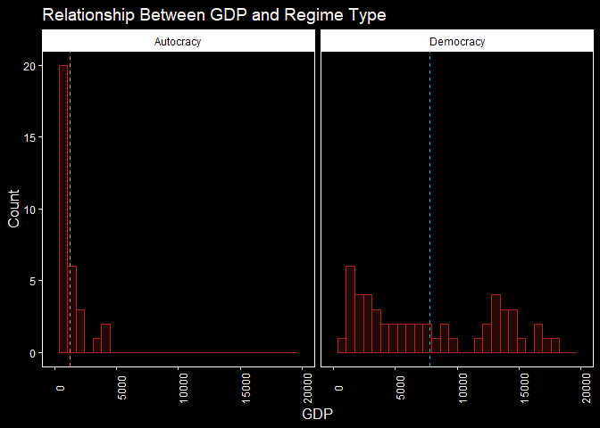

```r
#Subsetting data
demo3<-dplyr::filter(demo1, regime!="Anoncracy")
#Creating mean line
mr<- plyr::ddply(demo3, "regime", summarise, mean=mean(gdp))
#Creating histogram plot
ggplot(demo3, aes(x=gdp, colour=regime))+
#Setting bin size to 10 and changing the colour of the plots to red
#Making the colour more transparent using alpha
  geom_histogram(bins=30,
                 colour="firebrick",
                 fill="firebrick",
                 alpha=0.2)+
#Changing the labels of the graph
  labs(x="GDP", y="Count",title="Relationship Between GDP and Regime Type")+
#Showing distribution of each regime type
  facet_wrap(~regime)+
#Altering the x-axis numeric scale
  scale_x_continuous(limits = c(0, 20000),
                     breaks = seq(from = 0, to=20000, by=5000))+

  dark_theme_linedraw()+
  theme(axis.text.x = element_text(angle = 90))+
  theme(panel.grid.major = element_blank(),
        panel.grid.minor = element_blank())+
  geom_vline(data=mr, aes(xintercept=mean, color=regime),
             linetype="dashed")+
  theme(legend.position="none")+
  font("title", size = 14, colour = "snow")+
  font("xy.title", size = 12, colour = "snow")+
  font("xy.text", color="snow")
```

# **Question Four - Part D - Interpretation of Graph**

Neither of the histograms look normal, for autocracy the histogram is skewed heavily to the right, meaning that autocracies tend to have a low GDP. Whereas, the histogram for democracies is closer to a bimodal distribution, meaning most democracies tend to have a low or high GDP.

# **Question Four - Part E**

```r
# Joint probability of Regime type and Wealth
JP<-demo
JP$regime<-as.character(JP$regime)
JP$wealth<-as.character(JP$wealth)
#Recoding the values of the wealth variable
JP$wealth<- car::recode(JP$wealth,"'1'='Poor';'2'='Middle Income'; '3'='Rich'")
#Recoding the values of regime variable
JP$regime<- car::recode(JP$regime,"'1'='Autocracy';'2'='Anocracy'; '3'='Democracy'")

#Calculating the joint probability and rounding the percentage
JP<-JP%>%
  dplyr::count(wealth, regime)%>%
  dplyr::mutate("prob" = 100*(n/sum(n)))%>%
  mutate(prob = sprintf("%0.2f", prob))%>%
  dplyr::select(-n)%>%
  tidyr::pivot_wider(names_from=regime, values_from=prob)%>%
  rename(Wealth=wealth)

#Pasting % sign onto values
JP$Anocracy<- paste(JP$Anocracy, "%")
JP$Autocracy<- paste(JP$Autocracy, "%")
JP$Democracy<- paste(JP$Democracy, "%")

#Creating table to present the results
kable(JP)%>%kable_styling(bootstrap_options = c("hover", "condensed"))%>%
  kable_material_dark()%>%
  column_spec(1, bold=TRUE,  color="white")%>%
  row_spec(0, bold=TRUE, color="white")%>%
  row_spec(1:3, color="black")
```

| Wealth | Anocracy | Autocracy | Democracy |
| --- | --- | --- | --- |
| Middle Income | 14.29 % | 5.71 % | 19.05 % |
| Poor | 4.76 % | 24.76 % | 5.71 % |
| Rich | 0.95 % | NA % | 24.76 % |

# **Question Four - Part F**

The joint probability that a state is an anocracy and has middle income is 14.29%. This suggests that an anocracy is far more likely to have a middle income versus being rich or poor.

# **Question Four - Part G**

```r
MP<-demo
MP$regime<-as.character(MP$regime)
MP<-MP%>% count(regime) %>%
mutate("Probability" = 100*(n/sum(n)))%>%
mutate(Probability = sprintf("%0.2f", Probability))%>%
rename(Regime=regime, Count=n)

#Recoding the values of regime variable
MP$Regime<- car::recode(MP$Regime,"'1'='Autocracy';'2'='Anocracy'; '3'='Democracy'")

#Pasting % sign on probability values
MP$Probability<- paste(MP$Probability, "%")

#Presenting results in table
kable(MP)%>%kable_styling(bootstrap_options = c("hover", "condensed"))%>%
  kable_material_dark()%>%
  column_spec(1, bold=TRUE,  color="white")%>%
  row_spec(0, bold=TRUE, color="white")%>%
  row_spec(1:3, color="black")
```

| Regime | Count | Probability |
| --- | --- | --- |
| Autocracy | 32 | 30.48 % |
| Anocracy | 21 | 20.00 % |
| Democracy | 52 | 49.52 % |